# Casual Labour Wage Inequalities across States

Hrishant Singhal

23/03/2022

## Objective of the Study

The study aims to understand the factors that are responsible for the variation in casual labor wage disparities across Indian States.

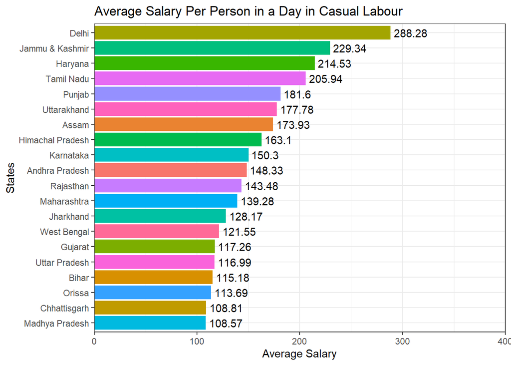

```r
library(tidyverse)
library(srvyr)
library(readxl)
library(ggrepel)
library(ggpubr)

# Loading the Data
setwd("D://Income - Casual Labour")
load("36151-0001-Data.rda")
main_data<-da36151.0001

#Prepping the Data
income_data<-main_data %>%
  #cleaning the state column
  separate(col=STATEID,into=c("No","State","No."),sep=c(5,-3)) %>%

  #selecting the columns we need
  select(state=State,duration=WS9,salary=WS10,nature=WS13,b3=WS12,
         weight=FWT,total=WSEARN,w_days=WS7,employer=WS14,edu_level=ED6,lit=ED2,
         area=URBAN2011,job=WS4,industry=WS5) %>%
  drop_na() %>%

  #taking out fixed payment jobs
  filter(duration %in% c("(2) Per Month 2","(1) Per Day 1")) %>%

  #converting all salary in daily basis and adding bonus
  mutate(sal_per_day=round(ifelse(duration=="(2) Per Month 2",
                            salary/30+b3/365,salary+b3/365))) %>%
  #Filtering only Casual Daily Workers
  filter(nature=="(1) Casual daily 1")

#Average wage and working days for each state
wdata<-income_data %>%
  as_survey(weights = c(weight)) %>%
  group_by(state) %>%
  summarise(wd=survey_mean(w_days),
            wage=round(survey_mean(sal_per_day),2)) %>%
  mutate(state=fct_reorder(state,wage))

#importing SDP file and keeping only top 22 states (excluding Kerala, reasons for excluding Kerala have been mentioned at the end) and doing some data cleaning before combining
sdp<-read_excel("sdp.xlsx")
gdp_dat<-sdp %>% top_n(22) %>% filter(State!="Kerala") %>% select(state=State,SDP)
gdp_dat$state[gdp_dat$state=="Odisha"]<-"Orissa"
gdp_dat$state[gdp_dat$state=="Jammu and Kashmir"]<-"Jammu & Kashmir"

pd_dat<-merge(gdp_dat,wdata)
#Telangana was a part of the GDP Data but IHDS did not have Telangana as a separate state during survey so it has been omitted.

#Plotting the Graph of average wage in each state
pd_dat %>% ggplot(aes(x=wage,y=fct_reorder(state,wage),fill=state)) +
  geom_bar(stat="identity") +
  xlab("Average Salary") +
  ylab("States") +
  theme_bw() +
  theme(legend.position="none") +
  ggtitle("Average Salary Per Person in a Day in Casual Labour") +
  scale_x_continuous(limits = c(0, 400),expand=c(0,0)) +
  geom_text(aes(label=wage),hjust=-0.1)
```

## Testing the Existing Theories with Data from IHDS, 2011

#### 1. **[India Wage Report, 2018](https://www.ilo.org/wcmsp5/groups/public/---asia/---ro-bangkok/---sro-new_delhi/documents/publication/wcms_638305.pdf) – Considered the association between the SDP of each state and its nominal casual labor wages and found a very weak correlation of 0.5 so it concluded that no conclusion could be drawn from that.**

ILO looked separately at the rural and urban wage correlation with the nominal casual labor wages, which implied that it believed there is little association between rural and urban wages of a state.

I find that there is a strong association between urban and rural wages.

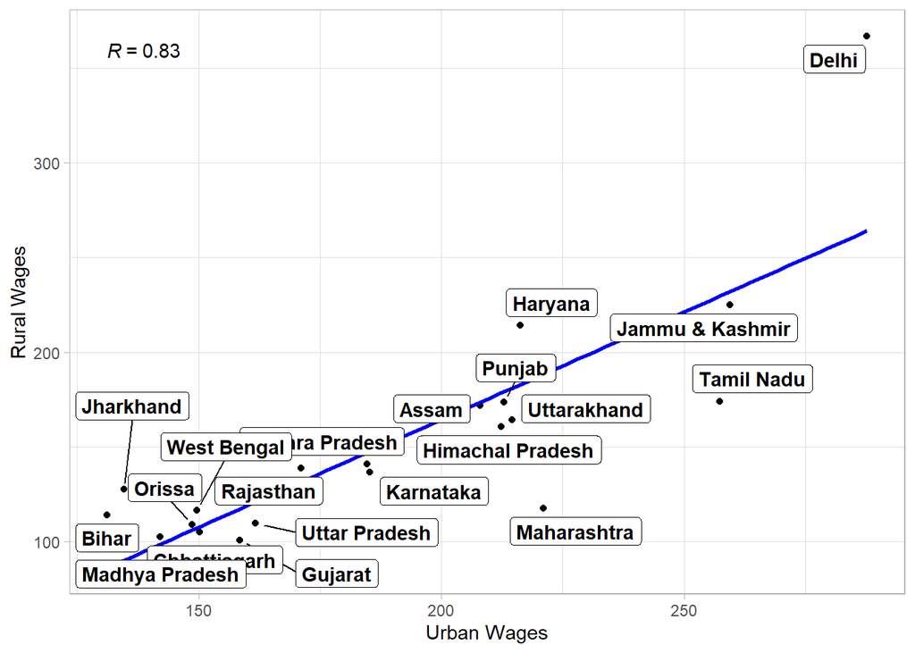

```r
#importing per_capita GDP file
Per_Capita_SDP_State <- read_excel("Per_Capita_SDP_State.xlsx") %>% rename(state=State)
Per_Capita_SDP_State$state[Per_Capita_SDP_State$state=="Odisha"]<-"Orissa"
Per_Capita_SDP_State$state[Per_Capita_SDP_State$state=="Jammu and Kashmir"]<-"Jammu & Kashmir"

#Filtering Rural Wages
rural_wage<-income_data %>% filter(area=="(0) rural 0") %>%
  as_survey(weights = c(weight)) %>%
  group_by(state) %>%
  summarise(rural_wd=survey_mean(w_days),
            rural_wage=round(survey_mean(sal_per_day),2)) %>%
  mutate(state=fct_reorder(state,rural_wage))

#Filtering Urban Wages
urban_wage<-income_data %>% filter(area=="(1) urban 1") %>%
  as_survey(weights = c(weight)) %>%
  group_by(state) %>%
  summarise(urban_wd=survey_mean(w_days),
            urban_wage=round(survey_mean(sal_per_day),2)) %>%
  mutate(state=fct_reorder(state,urban_wage))

#Combining all 3 files with the existing file
pd_dat<-merge(pd_dat,rural_wage)
pd_dat<-merge(pd_dat,urban_wage)
pd_dat<-merge(pd_dat,Per_Capita_SDP_State)

#Plotting Urban and Rural Wages
ruralwage_urbanwage<-pd_dat %>% ggplot(aes(x=urban_wage,y=rural_wage,label=state)) +
  geom_point() +
  geom_smooth(method = "lm", se=FALSE, color="blue", formula = y~x) +
  stat_cor(method = "pearson", aes(label = ..r.label..)) + xlab("Urban Wages") +
  geom_label_repel(aes(fontface = 'bold'),box.padding = unit(0.25, 'lines'),point.padding = unit(0.5, 'lines'),max.overlaps = 30) +
  ylab("Rural Wages") + theme_light()

ruralwage_urbanwage
```

So, we can look at the per capita SDP of the state and its average wages (without making distinctions for urban and rural areas), I find a correlation value of 0.73.

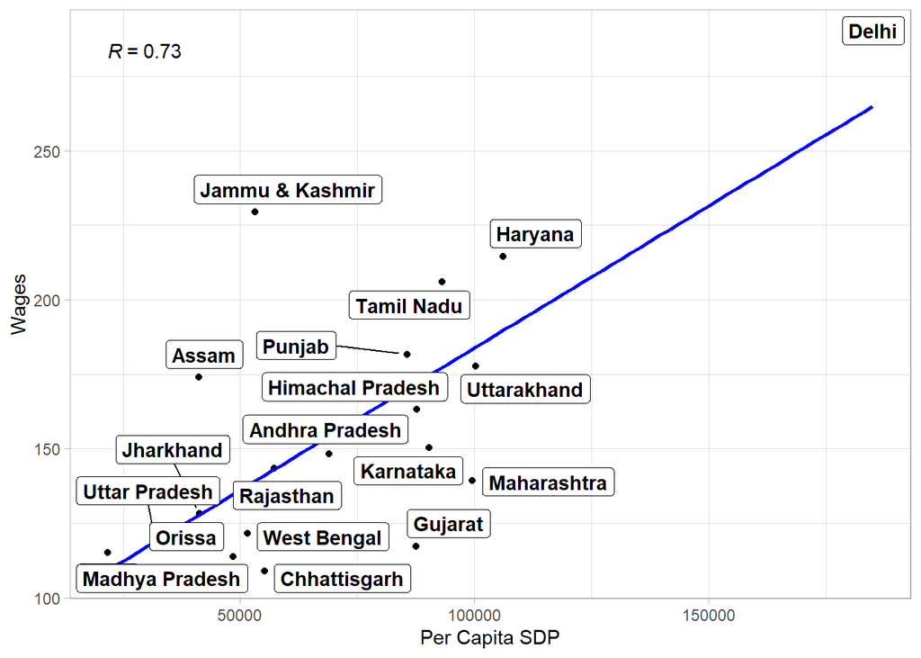

```r
wage_percapitaSDP<-pd_dat %>% ggplot(aes(x=per_capita,y=wage,label=state)) +
  geom_point() +
  geom_smooth(method = "lm", se=FALSE, color="blue", formula = y~x) +
  stat_cor(method = "pearson", aes(label = ..r.label..)) + xlab("Per Capita SDP") +
  geom_label_repel(aes(fontface = 'bold'),box.padding = unit(0.25, 'lines'),point.padding = unit(0.5, 'lines'),max.overlaps = 30) +
  ylab("Wages") + theme_light()

wage_percapitaSDP
```

#### **2. [AV Jose, 2013](https://www.jstor.org/stable/23527238) – Land and Labor Productivity can explain differences in Rural Wages across Indian States**

He argues that if land is more productive then quantity of food crops produced will be higher and so the wages of the farmers would be higher too.

He writes, “A strong correspondence observed between per capita state domestic product (sdp) and wages point to the likelihood of the former becoming an important determinant.” Calculations from the IHDS data corroborates this as well.

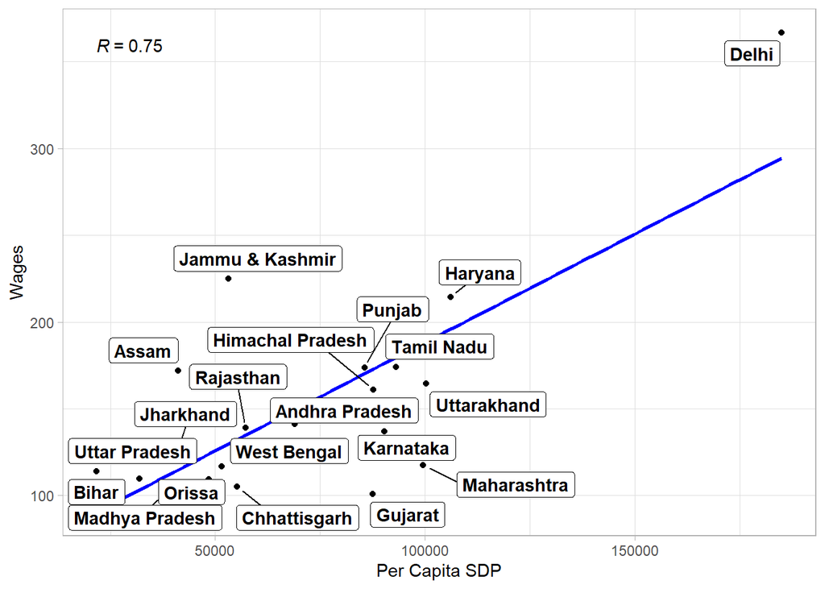

```r
ruralwage_percapitaSDP<-pd_dat %>% ggplot(aes(x=per_capita,y=rural_wage,label=state)) +
  geom_point() +
  geom_smooth(method = "lm", se=FALSE, color="blue", formula = y~x) +
  stat_cor(method = "pearson", aes(label = ..r.label..)) + xlab("Per Capita SDP") +
  geom_label_repel(aes(fontface = 'bold'),box.padding = unit(0.25, 'lines'),point.padding = unit(0.5, 'lines'),max.overlaps = 30) +
  ylab("Wages") + theme_light()

ruralwage_percapitaSDP
```

But as he warns, “One should, however, be cautious about generalising on the strength of a causal relationship, because the SDP is a composite average of output originating in agricultural and non-agricultural sectors. Ideally we should take into account product per worker in agriculture of different states if we were to were to try and establish any direct relationship between productivity and wages.“

My calculations show that there is no association between rural wages and product per worker in agriculture.

The product per worker has been calculated by dividing the total contribution of agriculture in the state’s GDP by the total number of people engaged in agriculture in the state.

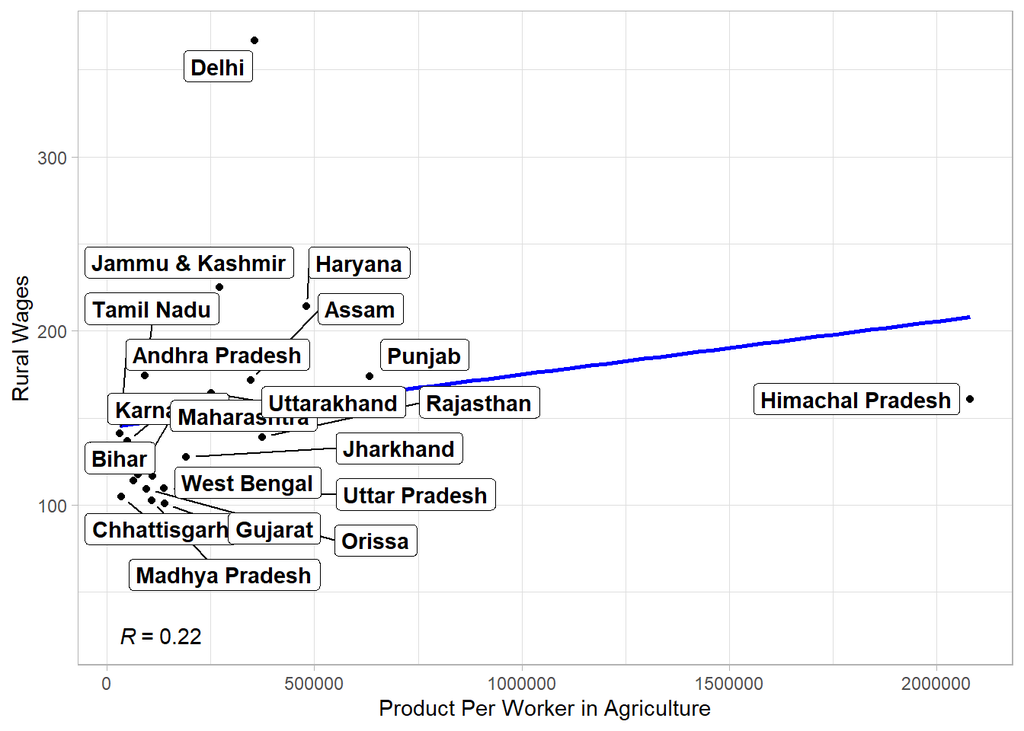

```r
agri_state<-read_excel("Agriculture_State.xlsx") %>% rename(state=State)
agri_state$state[agri_state$state=="Odisha"]<-"Orissa"
agri_state$state[agri_state$state=="Jammu and Kashmir"]<-"Jammu & Kashmir"

pd_dat<-merge(pd_dat,agri_state)

people_in_agri<-income_data %>% as_survey(weights = c(weight)) %>% group_by(state,industry) %>%
  summarize(n = survey_total()) %>%
  arrange(-n) %>% filter(industry=="(00) Agriculture 0") %>% select(state,n_in_agri=n)

pd_dat<-merge(pd_dat,people_in_agri)

peopleagri_sdp<-pd_dat %>% ggplot(aes(x=(agri*100000)/n_in_agri,y=rural_wage,label=state)) +
  geom_point() +
  geom_smooth(method = "lm", se=FALSE, color="blue", formula = y~x) +
  stat_cor(method = "pearson", label.y=25,aes(label = ..r.label..)) +
  xlab("Product Per Worker in Agriculture") +
  geom_label_repel(aes(fontface = 'bold'),box.padding = unit(0.25, 'lines'),point.padding = unit(0.5, 'lines'),max.overlaps = 30) +
  ylab("Rural Wages") + theme_light()

peopleagri_sdp
```

Though we find a moderate association between agricultural wages and product per worker in agriculture. Jammu and Kashmir is an outlier, without its presence the correlation coefficient jumps up to 0.75.

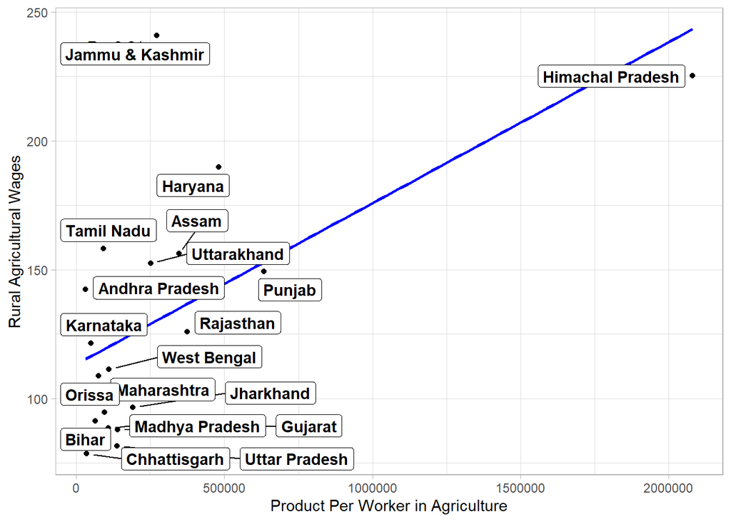

```r
#Prepping the Data
income_data_agri<-main_data %>%
  #cleaning the state column
  separate(col=STATEID,into=c("No","State","No."),sep=c(5,-3)) %>%

  #selecting the columns we need
  select(state=State,duration=WS9,salary=WS10,nature=WS13,b3=WS12,
         weight=FWT,total=WSEARN,w_days=WS7,employer=WS14,edu_level=ED6,lit=ED2,
         area=URBAN2011,job=WS4,industry=WS5) %>%
  drop_na() %>%

  #taking out fixed payment jobs
  filter(duration %in% c("(2) Per Month 2","(1) Per Day 1")) %>%

  #converting all salary in daily basis and adding bonus
  mutate(sal_per_day=round(ifelse(duration=="(2) Per Month 2",
                                  salary/30+b3/365,salary+b3/365))) %>%
  #Filtering only Casual Daily Workers who are engaged in Agriculture
  filter(nature=="(1) Casual daily 1",industry=="(00) Agriculture 0")

#Average wage and working days for each state
wdata_agri<-income_data_agri %>%
  as_survey(weights = c(weight)) %>%
  group_by(state) %>%
  summarise(wd=survey_mean(w_days),
            agri_wage=round(survey_mean(sal_per_day),2)) %>%
  mutate(state=fct_reorder(state,agri_wage))

pd_dat1<-merge(gdp_dat,wdata_agri)


#Filtering Rural Wages
rural_wage<-income_data_agri %>% filter(area=="(0) rural 0") %>%
  as_survey(weights = c(weight)) %>%
  group_by(state) %>%
  summarise(rural_wd=survey_mean(w_days),
            rural_wage=round(survey_mean(sal_per_day),2)) %>%
  mutate(state=fct_reorder(state,rural_wage))

#Combining all files with the existing file
pd_dat1<-merge(pd_dat1,rural_wage)
pd_dat1<-merge(pd_dat1,Per_Capita_SDP_State)
pd_dat1<-merge(pd_dat1,agri_state)
pd_dat1<-merge(pd_dat1,people_in_agri) %>% mutate(ppw=(agri*100000)/n_in_agri)

pd_dat1 %>% ggplot(aes(x=ppw,y=rural_wage,label=state)) +
  geom_point() +
  geom_smooth(method = "lm", se=FALSE, color="blue", formula = y~x) +
  stat_cor(method = "pearson", aes(label = ..r.label..)) + xlab("Product Per Worker in Agriculture") +
  geom_label_repel(aes(fontface = 'bold'),box.padding = unit(0.25, 'lines'),point.padding = unit(0.5, 'lines'),max.overlaps = 30) +
  ylab("Rural Agricultural Wages") + theme_light()
```

AV Jose was right that land and labour productivity does affect farmer’s income but since there are some states like Jharkhand, Uttarakhand, Rajasthan etc where proportion of farmers in the casual labour of rural areas is too low so land and labour productivity does not have any effect on rural income in general.

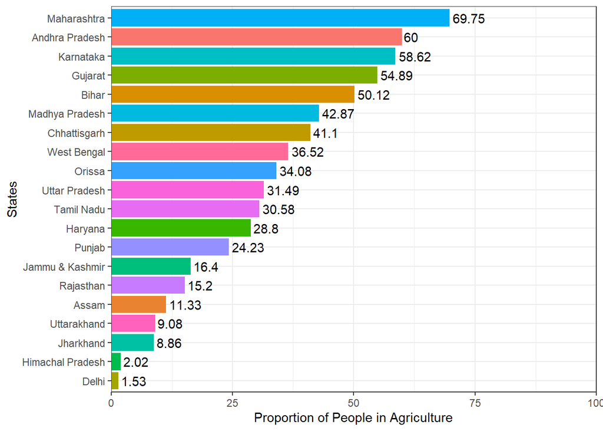

```r
#Finding Proportion of People Engaged in Agriculture in each State
prop_in_agri_state<-income_data %>% as_survey(weights = c(weight)) %>% group_by(state,industry) %>%
  summarize(n = survey_total()) %>% mutate(prop_in_agri=round(n*100/sum(n),2)) %>%
  arrange(-prop_in_agri) %>% filter(industry=="(00) Agriculture 0") %>%
  select(state,prop_in_agri)

#Merging it with the GDP Data
prop_in_agri_state<-merge(prop_in_agri_state,gdp_dat)

#Plotting the regression graph
prop_in_agri_state %>% ggplot(aes(x=prop_in_agri,y=fct_reorder(state,prop_in_agri),fill=state)) +
  geom_bar(stat="identity") +
  xlab("Proportion of People in Agriculture") +
  ylab("States") +
  theme_bw() +
  theme(legend.position="none") +
  scale_x_continuous(limits = c(0, 100),expand=c(0,0)) +
  geom_text(aes(label=prop_in_agri),hjust=-0.1)
```

## Proposed Model

It is difficult to include all the variations across wages in India into a neat analytical framework. There are factors like labor laws that are difficult to be included in the model. A variable that has not been mentioned in the studies that I read was “Percentage of People Engaged in Casual Labor in each state”.

Casual Labour is paid the most poorly among all the kinds of jobs. If people engaged in casual labor are higher in a state, then it shows that the state is not well developed, people are not well educated and need to do informal jobs so we would expect the average wages to be low for such a state.

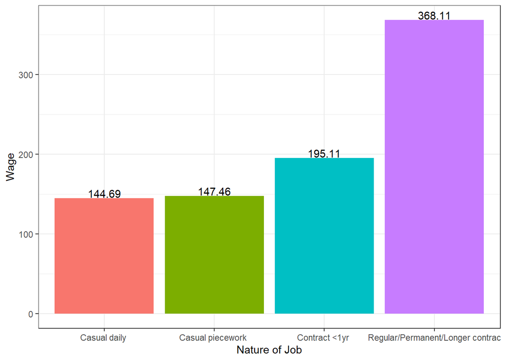

```r
#Data Prep
income_data_casual<-main_data %>%
  #cleaning the state column
  separate(col=STATEID,into=c("No","State","No."),sep=c(5,-3)) %>%

  #selecting the columns we need
  select(state=State,duration=WS9,salary=WS10,nature=WS13,b3=WS12,
         weight=FWT,total=WSEARN,w_days=WS7,employer=WS14,edu_level=ED6,lit=ED2,
         area=URBAN2011,job=WS4,industry=WS5) %>%
  drop_na() %>%

  #taking out fixed payment jobs
  filter(duration %in% c("(2) Per Month 2","(1) Per Day 1")) %>%

  #converting all salary in daily basis and adding bonus
  mutate(sal_per_day=round(ifelse(duration=="(2) Per Month 2",
                                  salary/30+b3/365,salary+b3/365)))
#Average Salary in each nature of job
income_data_casual %>%
  as_survey(weights = c(weight)) %>%
  group_by(nature) %>%
  summarise(wage=round(survey_mean(sal_per_day),2)) %>%
  separate(col=nature,into=c("n","nature","n."),sep=c(4,-1)) %>%
  ggplot(aes(x=fct_reorder(nature,wage),y=wage,fill=nature)) +
  geom_bar(stat="identity") +
  theme_bw() +
  theme(legend.position="none") +
  xlab("Nature of Job") +
  ylab("Wage") +
  geom_text(aes(label=wage),vjust=-0.1)
```

Our data shows that this theory holds, there is a strong negative correlation between wages and the percentage of people engaged in casual labor in the state.

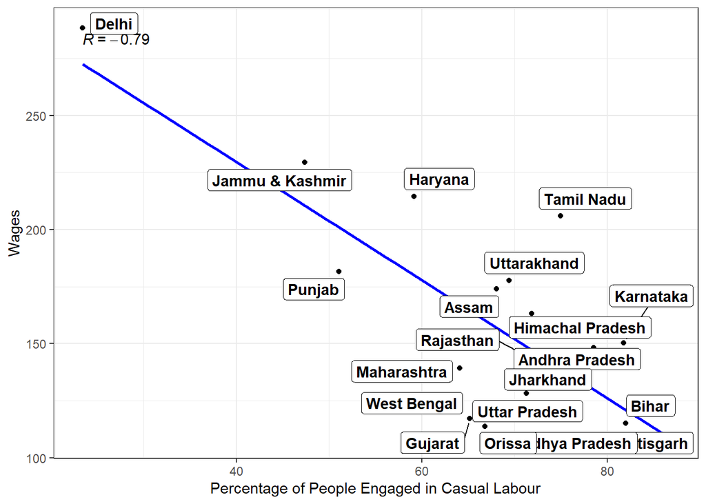

```r
#People in Casual Labour
prop_casual_labour=income_data_casual %>% as_survey(weights = c(weight)) %>% group_by(state,nature) %>%
  summarize(n = survey_total()) %>% mutate(casual_labour=round(n*100/sum(n),2)) %>%
  filter(nature=="(1) Casual daily 1") %>% select(state,casual_labour)

#Merging Previous with Casual Labour Data
pd_dat<-merge(pd_dat,prop_casual_labour)

#Plotting Linear Model
pd_dat %>% ggplot(aes(x=casual_labour,y=wage,label=state)) +
  geom_point() +
  geom_smooth(method = "lm", se=FALSE, color="blue", formula = y~x) +
  stat_cor(method = "pearson", aes(label = ..r.label..)) + xlab("Percentage of People Engaged in Casual Labour") +
  geom_label_repel(aes(fontface = 'bold'),box.padding = unit(0.25, 'lines'),point.padding = unit(0.5, 'lines'),max.overlaps = 30) +
  ylab("Wages") + theme_bw()
```

I propose this linear regression model to understand the wage variation.

$Wage_i$=$B_1$+$B_2$*$(Per Capita SDP)_i$+$B_3$*$(Percentage of People Engaged in Casual Labor)_i$+$e_i$

Our Regression Results give this output:

```r
#Proposed Model
library(stargazer)
regression_model<-lm(wage~per_capita+casual_labour,pd_dat)
stargazer(regression_model,type="text",align=TRUE,title="Regression Results")
```

```
Regression Results
===============================================
                        Dependent variable:
                    ---------------------------
                               wage
-----------------------------------------------
per_capita                   0.0005**
                             (0.0002)

casual_labour                -1.755***
                              (0.587)

Constant                    240.712***
                             (52.840)

-----------------------------------------------
Observations                    20
R2                             0.698
Adjusted R2                    0.663
Residual Std. Error      27.861 (df = 17)
F Statistic           19.654*** (df = 2; 17)
===============================================
Note:               *p<0.1; **p<0.05; ***p<0.01
```

## Conclusion

We find that there is a positive association with wages of casual labour in per capita SDP of Indian States. When the state grows richer, it increases the wages of the least well of along with it.

There is also a strong negative association with the number of people employed in casual labour in the states. If people engaged in casual labor are higher in a state, then it shows that the state is not well developed, people are not well educated and need to do informal jobs so we would expect the average wages to be low for such a state.

## Variables that had to be left out of the model due to issues of multicolinearity or insignificant results .

Literate People have higher income on average.

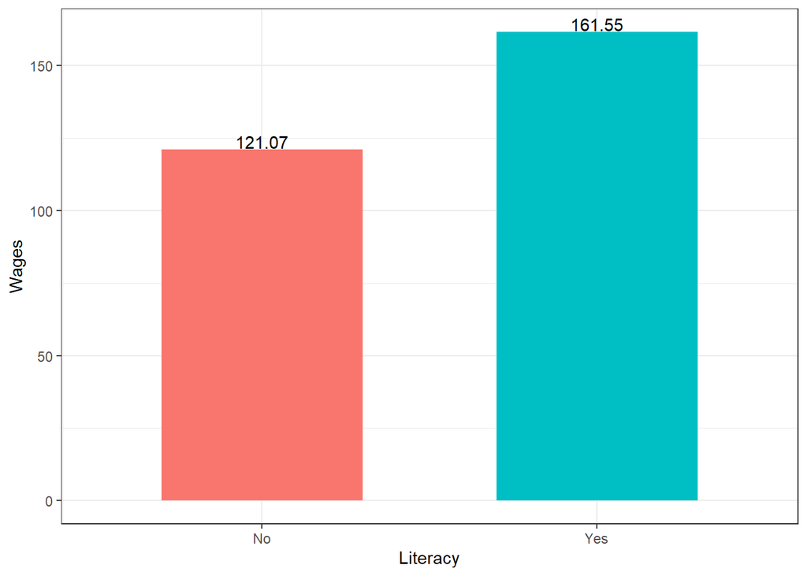

```r
#Average wages for literates and illiterates
income_data %>% as_survey(weights = c(weight)) %>%
  group_by(lit) %>%
  summarise(wage=round(survey_mean(sal_per_day),2)) %>%
  separate(col=lit,sep=c(4,-2),into=c("n","literate","no.")) %>% select(literate,wage) %>%
  ggplot(aes(x=literate,y=wage,fill=literate)) + geom_bar(stat="identity",width=0.6) +
  theme_bw() +
  xlab("Literacy") +
  ylab("Wages") +
  theme(legend.position="none") +
  geom_text(aes(label=wage),vjust=-0.1)
```

```r
#Proportion of Literates in each state
lit_state<-income_data %>% as_survey(weights = c(weight)) %>% group_by(state,lit) %>%
  summarize(n = survey_total()) %>%
  mutate(n_prop=n*100/sum(n)) %>% filter(lit=="(1) Yes 1") %>%
  select(state,n_prop)

#Combining with the previous data
pd_dat<-merge(pd_dat,lit_state)

cat(paste("But the correlation Coefficient between wages and percentage of literacy in each state is ",round(cor(pd_dat$n_prop,pd_dat$wage),2),", which is very insignificant.",sep=""))
```

[output not shown]

People with higher education have higher average wages in general.

```r
#Filtering Data at each education Level
library(DT)
edu_dat<-income_data %>% as_survey(weights = c(weight)) %>%
  group_by(edu_level) %>%
  summarise(wage=round(survey_mean(sal_per_day),2)) %>% select(edu_level,wage)

#cleaning the data
edu_dat$edu_level=as.character(edu_dat$edu_level)

edu_dat[14,1]="(13) 1 year post-secondary 13"
edu_dat[15,1]="(14) 2 year post-secondary 14"

#finally presenting it
abc<-edu_dat %>% separate(col=edu_level,into=c("n","edu_level","no"),sep=c(5,-2)) %>%
  select(`Education Level`=edu_level,`Average Wage`=wage)

datatable(abc)
```

|  | Education Level | Average Wage |
| --- | --- | --- |
| 1 | none | 121.25 |
| 2 | 1st class | 132.42 |
| 3 | 2nd class | 137.93 |
| 4 | 3rd class | 136.3 |
| 5 | 4th class | 140.45 |
| 6 | 5th class | 148.5 |
| 7 | 6th class | 157.4 |
| 8 | 7th class | 151.79 |
| 9 | 8th class | 156.93 |
| 10 | 9th class | 167.32 |

[output cut: 7 more lines]

To bring it into quantitative terms, I tried associating wages of each state with percentage of people who have passed fifth and tenth standard in each state.

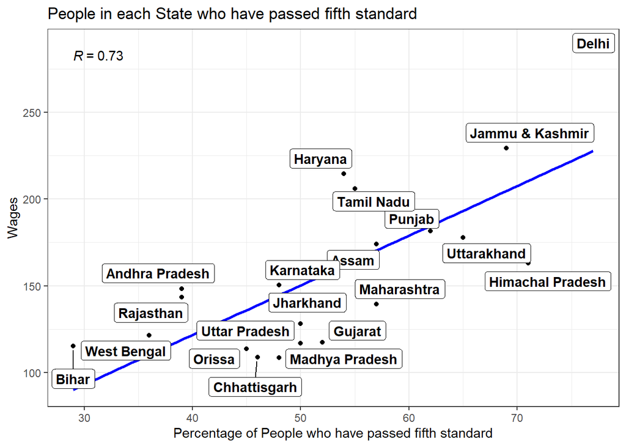

```r
fifth<-as.character(levels(income_data$edu_level))[6:17]
tenth<-as.character(levels(income_data$edu_level))[11:17]

#Finding people who have passed 5th and 10th
income_data<-income_data %>%
  mutate(tenthp=ifelse(edu_level %in% tenth,1,0),fifthp=ifelse(edu_level %in% fifth,1,0))

#Summarising for each state
passdat<-income_data %>% as_survey(weights = c(weight)) %>%
  group_by(state) %>% summarise(tenthpass=round(survey_mean(tenthp),2)*100,
                                   fifthpass=round(survey_mean(fifthp),2)*100) %>%
  select(state,tenthpass,fifthpass)
pd_dat<-merge(pd_dat,passdat)

#Plotting Scatterplot for 5th
pd_dat %>% ggplot(aes(x=fifthpass,y=wage,label=state)) +
  geom_point() +
  geom_smooth(method = "lm", se=FALSE, color="blue", formula = y~x) +
  stat_cor(method = "pearson", aes(label = ..r.label..)) + xlab("Percentage of People who have passed fifth standard") +
  geom_label_repel(aes(fontface = 'bold'),box.padding = unit(0.25, 'lines'),point.padding = unit(0.5, 'lines'),max.overlaps = 30) +
  ylab("Wages") + theme_bw() + ggtitle("People in each State who have passed fifth standard")
```

There is a strong association with wages and percentage of people having passed tenth standard.

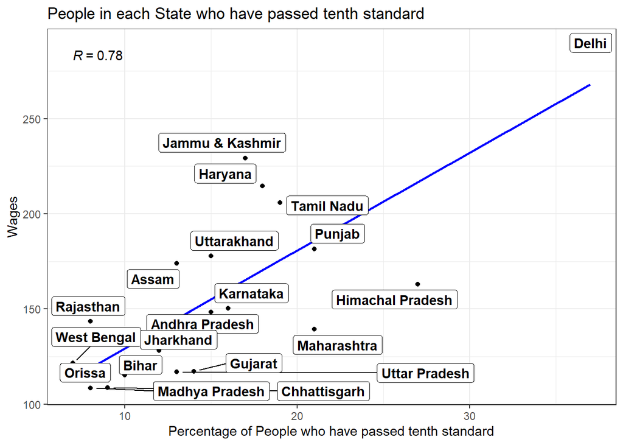

```r
#Plotting Scatterplot for 10th
pd_dat %>% ggplot(aes(x=tenthpass,y=wage,label=state)) +
  geom_point() +
  geom_smooth(method = "lm", se=FALSE, color="blue", formula = y~x) +
  stat_cor(method = "pearson", aes(label = ..r.label..)) + xlab("Percentage of People who have passed tenth standard") +
  geom_label_repel(aes(fontface = 'bold'),box.padding = unit(0.25, 'lines'),point.padding = unit(0.5, 'lines'),max.overlaps = 30) +
  ylab("Wages") + theme_bw() +ggtitle("People in each State who have passed tenth standard")
```

But due to issues of multicollinearity and insignificant results, these variables had to be left out of the model.